# Lab9 - Ordered and Multinomial Logistic Regression

Barum Park

11/22/2019

To understand **ordinal and multinomial logistic regression**, the best point to start is the **latent variable formulation** of the (binary) logistic regression model. The latent variable representation often appears in econometric textbooks, especially in the derivation of the probit model. We will first discuss the probit model, then show that the same model with a different distributional assumption of th error term leads to the logit model, and then pivot to ordinal and multinomial logit models.

# Latent Variable Formulation of the Probit Model

Suppose you have a “latent” (i.e., unobserved) outcome $y^\ast$ which is continuous. We assume that this latent variable is generated by the following data-generating process
$$Y^\ast = \alpha + X_i\beta + \epsilon^\ast.$$
Suppose further that the error term, which we don’t observe as well, has the following distribution
$$\epsilon^\ast \sim \text{Normal}(0,1),$$

If we would observe the latent variable $Y^\ast$, we could simply run an OLS regression to estimate the regression coefficients $(\alpha, \beta)$. Unfortunately, by construction, $Y^\ast$ is unobservable (it’s latent!). Suppose that we observe only a truncated version of the latent variable. Namely, we observe the variable $Y$ which is related to the latent variable $Y^\ast$ by the following relationship:
$$Y = \begin{cases}1, \quad &\text{if } Y^\ast > 0 \\
0, &\text{otherwise} \end{cases}$$
You can think of the value $0$ as a “threshold” that determines what outcome we observe in the data: if $Y^\ast$ is larger than 0, we observe $Y = 1$; if $Y^\ast$ is smaller than zero, we observe $Y=0$.

One point to notice, which will help us later, is that this threshold is arbitrary. For example, we could choose any other value as the threshold and obtain the same outcome by re-defining the constant term of the latent regression equation. To illustrate, let us choose an arbitrary value $a$ as the new threshold; then we would observe $Y = 1$ only if $Y^\ast > a$. Further, the probability of observing $Y = 1$ would be
$$\begin{aligned}
\Pr[Y^\ast > a] &= \Pr[\alpha + \beta X + \epsilon^\ast > a] \\
&=\Pr[ (\alpha- a) + \beta X + \epsilon^\ast > 0] \\
&=\Pr[ \alpha^\ast + \beta X + \epsilon^\ast > 0],
\end{aligned}$$
where $\alpha^\ast = \alpha - a$. Hence, even if our initial threshold value was $a$, we can simply redefine the constant term of the regression as $\alpha^\ast = \alpha - a$, and change the threshold value back to zero. For both of these models, the probability of observing $Y = 1$ would be exactly the same. In fact, we could also have decided that we don’t want any constant in our regression equation at all and set the threshold to $-\alpha$; all of these different formulations would lead to the same probabilities of $Y = 1$.

The model with the latent variable $Y^\ast$ and the observed binary variable $Y$ is called the **probit** model. As with other regression models, our goal is to estimate the regression coefficients $\alpha$ and $\beta$. To do so, we observe that the following holds: Let $\Phi$ be the cumulative distribution function of a standard Normal random variable. That is, $\Phi(x) = \Pr[X \le x]$, where $X \sim \text{Normal}(0,1)$. Recall that the probit model assumes that the latent error term $\epsilon^\ast$ follows this distribution, i.e., $\epsilon^\ast \sim \text{Normal}(0,1)$. Then, we have

$$\begin{aligned}
\pi_i(x_i) &= \Pr[Y_i = 1\,\vert\,X_i = x_i] & \\
&= \Pr[Y_i^\ast > 0\,\vert\, X_i = x_i] \\
&= \Pr[\alpha + \beta x_i + \epsilon_i^\ast > 0] \\
&= \Pr[\epsilon_i^\ast > - (\alpha + \beta x_i)] \\
&= 1-\Pr[\epsilon_i^\ast \le - (\alpha + \beta x_i)] \\
&= 1 - \Phi\left(-[\alpha + \beta x_i]\right) \\
&= \Phi\left(\alpha + \beta x_i\right),
\end{aligned}$$
where the last step follows from the fact that the standard Normal distribution is symmetric about zero. A regression model of the form

$$\pi_i(x_i) = \Phi\left(\alpha + \beta x_i\right)$$

is called a probit model. Notice that the left-hand side is the probability that a Bernoulli random variable, $Y_i$, is equal to one (conditional on the predictor(s) $X_i$). The right-hand side is the combination of a link-function $\Phi$ and a linear combination of our predictor(s). Thus, everything is the same as the logistic regression model, except for the link function.

# Latent Variable Formulation of the Logit Model

The logistic regression model can be derived in the same way, by changing the distributional assumption of the “latent” error term, $\epsilon^\ast$. Namely, for the logistic regression model, we assume that $\epsilon^\ast \sim \text{Logistic}(0, 1)$, i.e., that the error term follows a Logistic distribution with location and scale parameters, respectively, equal to zero and one. Again, I hope you are not scared away by the appearance of a new distribution. The Logistic distribution looks quite similar to the Normal distribution; you can think of it as “just” another distribution that people have invented in the past.

To give you an intuitive feeling of the $\text{Logistic}(0,1)$ distribution, we might plot it together with a $\text{Normal}(\mu = 0, \sigma = 1.8)$ distribution:

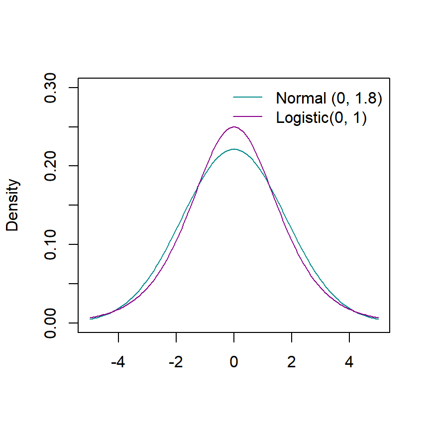

```r
# values at which to plot distributions
x = seq(-5, 5, .05)

# plot Normal(0, 1.8) distribution first
plot(x, dnorm(x, 0, 1.8), type = "l", col = "darkcyan",
     ylab = "Density", xlab = NA, ylim = c(0, .3))
# add Logistic(0,1) distribution
lines(x, dlogis(x), col = "darkmagenta")

# add legend
legend("topright", col = c("darkcyan", "darkmagenta"),
       lty = c(1,1), legend = c("Normal (0, 1.8)", "Logistic(0, 1)"),
       bty = "n")
```

As you can see the distributions look very similar; both distributions are symmetric around its mean and are bell-shaped.

The cumulative distribution function of a logistic random variable, call it $\Lambda$, has a now-familiar form:

$$\Lambda(x) = \frac{1}{1 + e^{-x}}.$$

Notice that this is exactly the the same function we have denoted by $\text{logit}^{-1}$ in the [previous lab](https://htmlpreview.github.io/?https://github.com/baruuum/intro_to_stats_2019/blob/master/Lab8/Lab8.html#treating-pid-as-a-categorical-variable).

Now, notice that the first five equations in the derivation of the probit model will hold regardless of which distribution we assume for $\epsilon_i^\ast$ (we are using only the basic properties of probability); the sixth line, on the other hand, will us lead us to $1 - \Lambda(-[\alpha + \beta x_i])$, but as the logistic distribution is symmetric, similarly to the Normal distribution, we arrive at

$$\pi_i(x_i) = \Lambda(\alpha + \beta x_i) = \text{logit}^{-1}(\alpha + \beta x_i),$$

which is exactly the same formulation of the logistic regression model that was introduced in the [previous lab](https://htmlpreview.github.io/?https://github.com/baruuum/intro_to_stats_2019/blob/master/Lab8/Lab8.html#treating-pid-as-a-categorical-variable). In other words, the data-generating process of the logistic regression model can be expressed as “latent” linear regression where the error term has a $\text{Logistic}(0,1)$ distribution.

Let me convince you that these are the same models by simulation. Namely, let us simulate a sample from the latent variable formulation, fit a logistic regression model, and compare the true coefficients to the estimated coefficients. If these two sets of coefficients are sufficiently close, we might be convinced that the latent variable representation and the logit representation we dealt with in the previous lab might be indeed the same models:

```r
# set seed
set.seed(123)

# set observations
n = 25000

# beta-vector (constant, beta1, beta2)
beta = c(-.5, .75, .2)

# first predictor (continuous)
x1 = runif(n, -1, 1)

# second predictor (dummy)
x2 = sample(c(0,1), n, replace = T)

# generate latent error term ~ Logistic(0, 1)
e_star = rlogis(n)

# generate latent outcome y_star
y_star = beta[1] + beta[2] * x1 + beta[3] * x2 + e_star

# set observed outcome equal to 1 if y_star > 0 and set it to 0 otherwise
y = ifelse(y_star > 0, 1, 0)

# fit a logistic regression to the simulated dataset
lreg = glm(y ~ x1 + x2, family = binomial(link = "logit"))

# compare true to estimated coefficients
rbind(Estimated = coef(lreg),
      True = beta)
```

```
##           (Intercept)        x1        x2
## Estimated  -0.4918727 0.7449186 0.2102779
## True       -0.5000000 0.7500000 0.2000000
```

which is quite close!

# Ordered Logistic Regression

You might ask why we go through all of this. The reason is that the latent variable formulation can be easily extended to the **ordered logistic regression model**. Recall that we had one threshold in the latent variable formulation of the probit/logit model, namely the value $0$. For the ordered logistic regression model, we consider multiple thresholds.

Let us start with the model
$$Y_i^\ast = \alpha + \beta_i X_i + \epsilon_i^\ast,$$
where $\epsilon_i^\ast \sim \text{Logistic}(0,1)$. But for the ordinal logistic regression case, we change two things.

1. Instead of estimating a constant of the regression and setting the threshold to zero, we set the constant to zero and estimate the threshold. As shown above, this will lead to the same probabilities as
   $$\alpha + \beta x_i + \epsilon_i^\ast> 0 \iff \beta x_i + \epsilon_i^\ast > - \alpha.$$
   Hence, by defining $\tau_1 = -\alpha$ as our first threshold and assuming that the latent regression model has no constant, we will obtain the same probabilities.
2. To link the latent regression with the observed outcome, which is no longer binary but has $K$ ordered responses, we will to estimate $K - 1$ threshold parameters, namely $\tau_1, \tau_2, ..., \tau_{K-1}$.

This is all fairly abstract. So, let us use the simplest example: an ordered logistic regression where the outcome has 3 ordered categories—i.e., $Y_i \in \{1,2,3\}$—and we have a single predictor, $X_i$. To link the latent variable to the observed one, we will need two thresholds, which we denote by $\tau_1$ and $\tau_2$. The relationship between the latent and observed outcome is then modeled by the function:
$$Y_i = \begin{cases}
1, \quad &\text{if } Y_i^\ast < \tau_1^\ast \\
2, \quad &\text{if } \tau_1^\ast \le Y_i^\ast < \tau_2^\ast \\
3, &\text{if } Y_i^\ast \ge \tau_2
\end{cases}$$
Suppose $\tau_1 = -0.5$ and $\tau_2 = 2$, then we might imagine the relationship between $\beta X_i$ and the response probabilities in the following way. Suppose $\beta = 0.75$ and and $X_i = 0$. Then $Y_i^\ast = \epsilon_i^\ast$, where $\epsilon_i^\ast \sim \text{Logistic}(0,1)$. So, $Y^\ast \sim \text{Logistic}(0,1)$ and the probabilities to observe the outcomes $1,2,3$ would be

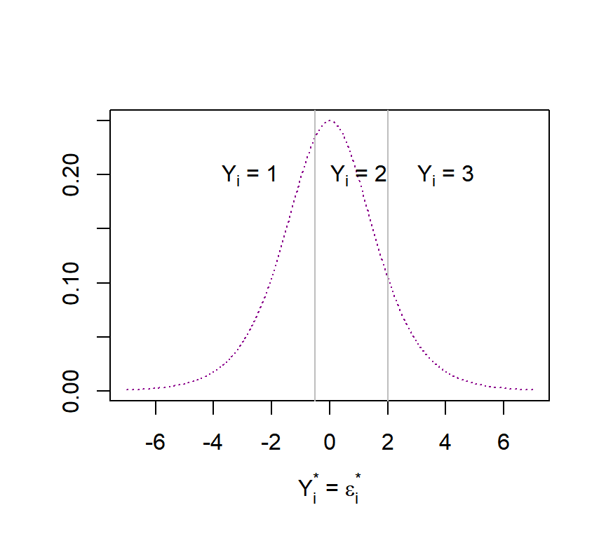

```r
# grid to plot distribution
x = seq(-7, 7, .01)

# threshold values
tau = c(-0.5, 2)

# plot logistic curve
plot(x, dlogis(x), type = "l", lty = 3, col = "darkmagenta",
     xlab = expression(paste(Y[i]^"*", " = ", epsilon[i]^"*")),
     ylab = "")

# plot thresholds
abline(v = tau, col = "grey")

# plot outcome labels
text(-2.75, .2, expression(paste(Y[i], " = 1")))
text(1, .2, expression(paste(Y[i], " = 2")))
text(4, .2, expression(paste(Y[i], " = 3")))
```

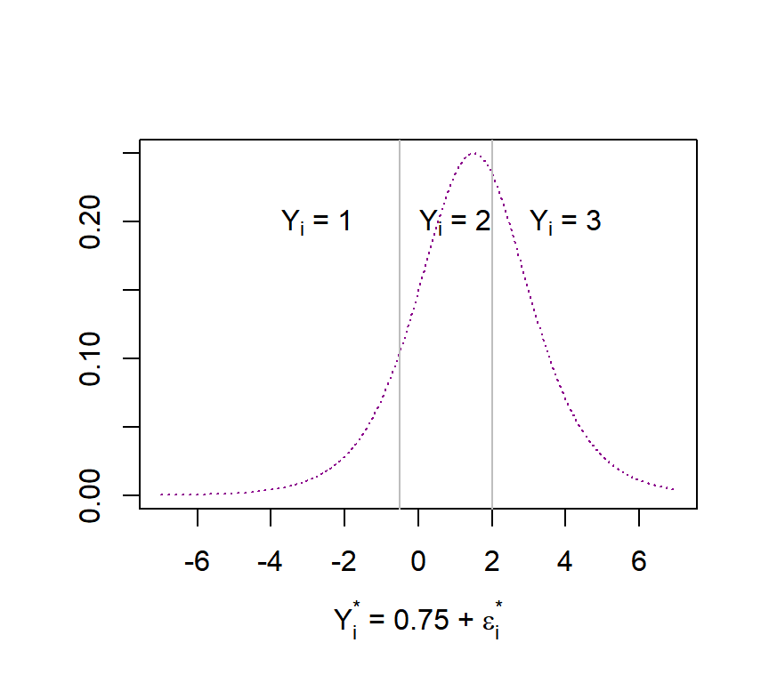

```r
# plot logistic curve
plot(x, dlogis(x, 1.5), type = "l", lty = 3, col = "darkmagenta",
     xlab = expression(paste(Y[i]^"*"," = 0.75 + ", epsilon[i]^"*")),
     ylab = "")

# plot thresholds
abline(v = tau, col = "grey")

# plot outcome labels
text(-2.75, .2, expression(paste(Y[i], " = 1")))
text(1, .2, expression(paste(Y[i], " = 2")))
text(4, .2, expression(paste(Y[i], " = 3")))
```

Let me, again, illustrate how this work via simulation. To fit a ordered logistic regression model in R, we’ll use the `polr` function from the `MASS` package. So, let us first install the package:

```r
install.packages("MASS")
```

We load also some other packages that we need:

```r
library(dplyr)
library(data.table)
library(dtplyr)
library(ggplot2)
```

Now, here comes the simulation:

```r
# obs
n = 25000

# coefficients
beta = c(.8, .25)

# predictors (dummy & continuous)
x1 = sample(c(0, 1), n, replace = T)
x2 = runif(n, -2, 2)

# thresholds
tau = c(-.5, 2)

# generate latent outcome
ystar = x1 * beta[1] + x2 * beta[2] + rlogis(n)

# generate obseved outcome
y = ifelse(
    ystar < tau[1], 1,
        ifelse(ystar >= tau[1] & ystar < tau[2], 2, 3)
)

# construct dataset
olog_dat = data.table(y, x1, x2)

# fit ordered logistic regression
olog_fit = MASS::polr(factor(y) ~ x1 + x2, data = olog_dat)

# summarize
summary(olog_fit)
```

```
##
## Re-fitting to get Hessian
```

```
## Call:
## MASS::polr(formula = factor(y) ~ x1 + x2, data = olog_dat)
##
## Coefficients:
##     Value Std. Error t value
## x1 0.8026    0.02487   32.27
## x2 0.2530    0.01061   23.85
##
## Intercepts:
##     Value    Std. Error t value
## 1|2  -0.5110   0.0178   -28.6875
## 2|3   1.9850   0.0224    88.7780
##
## Residual Deviance: 48864.97
## AIC: 48872.97
```

This is, again, extremely close, which should be expected given that the sample size is large and our estimator is consistent.

The interpretation of these coefficients is a little bit annoying. For example, the estimate $\hat\beta_2 = .253$ would show us that a unit-increase in $X_2$ is associated with a $.253$ increase of the logged odds of giving a “higher” response. But what does this even mean? As with other models, plotting your results is often the most helpful way to present them.

For the simulate data, we might first fix `x1 == 1` and let `x2` vary and see how the predicted probabilities of the three categories change with changes in `x2`.

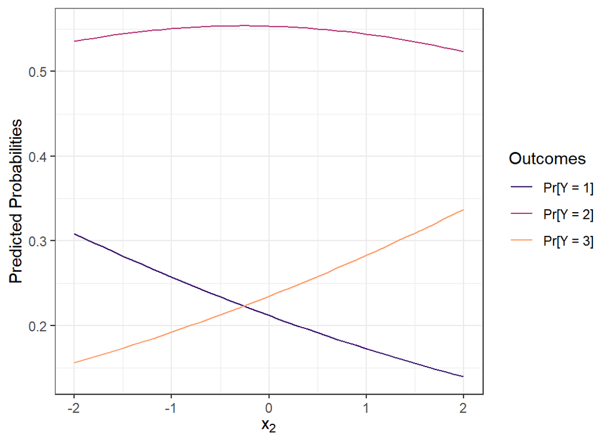

```r
# new dataset for predictions
new_dat = data.table(x1 = 1, x2 = seq(-2, 2, .1))

# obtain predicted probabilities
yhat = data.table(
    new_dat[, x2],
    predict(olog_fit, newdata = new_dat, type = "p")
)

# rename variables
setnames(
    yhat,
    c("x2", "Pr[Y = 1]", "Pr[Y = 2]", "Pr[Y = 3]")
)

# reshape into long form
yhat_long = melt(
    data = yhat,
    id.vars = "x2",
    variable.name = "outcome",
    value.name = "pred.prob")

# plot
ggplot(yhat_long, aes(x = x2, y = pred.prob, col = outcome)) +
    geom_line() +
    theme_bw() +
    labs(y = "Predicted Probabilities",
         x = expression(x[2])) +
    scale_color_viridis_d(
        name = "Outcomes",
        begin = .2,
        end = .8,
        option = "A")
```

Unfortunately, there is no straightforward way to calculate uncertainty estimates for these predictions. In fact, I was very surprised to find that setting `se = TRUE` in the `predict` function on a `polr` object doesn’t work.

In these situations, we can always rely on simulations to quantify our uncertainty. The material is a little bit advanced since it requires some knowledge of likelihood theory. So, it is added as an appendix.

# Multinomial Logistic Regression

The **multinomial logistic regression model** is used when the outcome is categorical but when the categories cannot be ordered. While there is also a latent variable formulation for this model, the derivation is much more technical and involves an understanding of the Extreme Type I (Gumbel) distribution. Hence, here I’ll skip this step and focus on how to simulate data from these models and how to fit them in R.

Recall that the multinomial logit model assumes that the probabilities of the outcomes $Y_i = 1,2,...,K$ are given as

$$\begin{aligned}
\pi_{i}^{(1)}(x_i) & = \Pr[Y_i = 1\,\vert\, X_i = x_i] = \frac{\exp(\alpha_1 + \beta_1 x_i)}{\sum_{k=1}^K \exp(\alpha_k + \beta_k x_i)} \\
\pi_{i}^{(2)}(x_i) & = \Pr[Y_i = 2\,\vert\, X_i = x_i] = \frac{\exp(\alpha_2 + \beta_2 x_i)}{\sum_{k=1}^K \exp(\alpha_k + \beta_k x_i)} \\
&\vdots \\
\pi_{i}^{(K)}(x_i) & = \Pr[Y_i = K\,\vert\, X_i = x_i] = \frac{\exp(\alpha_K + \beta_K x_1)}{\sum_{k=1}^K \exp(\alpha_K + \beta_k x_i)} \\
\end{aligned}$$

Notice that for each $i$, the outcome probabilities have to sum to one, since each unit $i$ must “choose” any of the $K$ option. For the representation above, this holds for *any* values of $\alpha_1, ..., \alpha_K, \beta_1,...,\beta_K$. That is, regardless of the values we choose for the regression coefficients, the following relationship will *always* hold:
$$\begin{aligned}
\sum_{k=1}^K \pi_i^{(k)}(x_i) &= \sum_{k=1}^K\left(\frac{\exp(\alpha_k + \beta_k x_i)}{\sum_{k=1}^K \exp(\alpha_k + \beta_k x_i)}\right) \\
& = \frac{\sum_{k=1}^K\exp(\alpha_k + \beta_k x_i)}{\sum_{k=1}^K \exp(\alpha_k + \beta_k x_i)} \\
& = 1.
\end{aligned}$$
If the relationship holds for any values of $\{\alpha_k, \beta_k\}_{k=1}^K$, there is no way to estimate these coefficients. Hence, we need to put some constraints on the regression coefficients. In the statistics literature, these constraints are often called *identification constraints*.

The most common constraint that is imposed in the multinomial logit model is to fix one of the outcomes as the **reference category** for which the corresponding regression coefficient will be equal to zero. Which category we choose is immaterial; so, let us use the first outcome category as the reference. When we set $\alpha_1 = \beta_1 = 0$, we have $\exp(\alpha_k + \beta_1 x_1) = 1.$ Hence, we can rewrite the outcome probabilities, with the constraint imposed, as

$$\begin{aligned}
\pi_{i}^{(1)}(x_i) & = \Pr[Y_i = 1\,\vert\, X_i = x_i] = \frac{1}{1 + \sum_{k=2}^K \exp(\alpha_k + \beta_k x_i)} \\
\pi_{i}^{(2)}(x_i) & = \Pr[Y_i = 2\,\vert\, X_i = x_i] = \frac{\exp(\alpha_2 + \beta_2 x_i)}{1 + \sum_{k=2}^K \exp(\alpha_k + \beta_k x_i)} \\
&\vdots \\
\pi_{i}^{(K)}(x_i) & = \Pr[Y_i = K\,\vert\, X_i = x_i] = \frac{\exp(\alpha_K + \beta_K x_1)}{1 + \sum_{k=2}^K \exp(\alpha_k + \beta_k x_i)} \\
\end{aligned}$$

When this parameterization is used, the exponentiated regression coefficients from the multinomial logit model can be interpreted in terms of **relative risk ratio**s. This makes the interpretation of the coefficients a bit more intuitive, compared to the coefficients from either binary or ordinal logistic regression.

The interpretation in terms of relative risk comes from the following relationship. First, the relative risk of falling into outcome category $k$ when $X_i = x_i$, compared to the risk of falling into the baseline category, is

$$\begin{aligned}
\frac{\pi_i(x_i)^{(k)}}{\pi_i(x_i)^{(1)}} &= \frac{\frac{\exp(\alpha_k + \beta_kx_i)}{1 + \sum_{k=2}^K \exp(\alpha_k + \beta_k x_i)}}{\frac{1}{1 + \sum_{k=2}^K \exp(\alpha_k + \beta_k x_i)}} \\
&= \exp(\alpha_k + \beta_kx_i) \\
&= \exp(\alpha_k) \exp(\beta_kx_i).
\end{aligned}$$
(Notice the left-hand side is the ratio of two *probabilities* and not *odds*). Similarly, the relative risk for the same outcome $k$ for $x_i + 1$ is
$$\frac{\pi_i(x_i + 1)^{(k)}}{\pi_i(x_i+1)^{(1)}} = \exp(\alpha_k) \exp[\beta_k(x_i + 1)].$$

Dividing the second by the first equation, we obtain
$$\begin{aligned}
\text{Relative Risk Ratio} &= \frac{\frac{\pi_i(x_i + 1)^{(k)}}{\pi_i(x_i+1)^{(1)}}}{\frac{\pi_i(x_i)^{(k)}}{\pi_i(x_i)^{(1)}}} \\
&= \frac{\exp(\alpha_k)\exp[\beta_k (x_i + 1)]}{\exp(\alpha_k)\exp(\beta_kx_i)} \\
&=\exp(\beta_k)
\end{aligned}$$

Hence, the relative risk of falling into the category $k$, instead of the baseline category, increases by **a factor** of $\exp(\beta_k)$.

To simulate a dataset from the multinomial logit model, we might use the following code. The code is rather complicated and you won’t need to understand it for the current course.

```r
# number of outcome categories
K = 4

# predictor matrix
X = cbind(1, x1, x2)

# regression coefficients (we need one element for each outcome category)
beta = cbind(
    rep(0, 3),
    c(-.75, 1.2, .4),
    c(.5, .25, -.95),
    c(.5, .4, .6)
)

# unnormalized predicted probs
raw_pred = exp(X %*% beta)

# normalize
pred = sweep(raw_pred, 1, rowSums(raw_pred), "/")

# draw outcome
y = apply(pred, 1, function(w) {
    sample.int(K, size = 1, prob = w)
})

# generate dataset
dat = data.table(y, x1, x2)
```

The important thing is that we have generated an outcome with `K = 4` categories and that the regression coefficients use to simulate the data are the following:

```r
beta
```

```
##      [,1]  [,2]  [,3] [,4]
## [1,]    0 -0.75  0.50  0.5
## [2,]    0  1.20  0.25  0.4
## [3,]    0  0.40 -0.95  0.6
```

where each column represents an outcome category (hence there are `K = 4`) and each row the regression coefficients of each predictor (including the constant). Notice that the first column of the `beta` matrix is filled with zero.